# CURSO DE ACTUALIZACION EN ESTADISTICA

#### Profesor: Dr. José Manuel MAGALLANES, Ph.D

## Sesión 7:

## **Medidas de Dispersión para Variables Numéricas**

Las medidas de dispersión para variables numéricas también nos informan qué tan concentrados están los valores en relación a las medidas de centralidad.

Veamos nuevamente los datos sobre viaticos:

```r
link='https://docs.google.com/spreadsheets/d/e/2PACX-1vRKNixPDRx-satxXqLVfuqEq4qBJuhyrVnoh5VJRguwqSgIh5lvJrgUg-khsypWXiUCBXbaFQ_uFEqW/pub?gid=1396607194&single=true&output=csv'

viaticos=read.csv(link, stringsAsFactors = F)
#
str(viaticos)
```

```
## 'data.frame':    1180 obs. of  8 variables:
##  $ PK_VIATICOS           : int  1985658 1985663 1985666 1985668 1985671 1985673 1985674 1985675 1985676 1985677 ...
##  $ FUENTE                : chr  "RECURSOS DIRECTAMENTE RECAUDADOS" "RECURSOS DIRECTAMENTE RECAUDADOS" "RECURSOS DIRECTAMENTE RECAUDADOS" "RECURSOS DIRECTAMENTE RECAUDADOS" ...
##  $ VC_RUC_ENTIDAD        : num  2.01e+10 2.01e+10 2.01e+10 2.01e+10 2.01e+10 ...
##  $ VC_VIATICOS_MES       : int  1 1 1 1 1 1 1 1 1 1 ...
##  $ VC_VIATICOS_AREA      : chr  "DIRECCIÓN GENERAL DE HIDROCARBUROS-N" "OFICINA GENERAL DE GESTIÓN SOCIAL -N" "DIRECCIÓN GENERAL DE FORMALIZACIÓN MINERA" "DIRECCIÓN TÉCNICA MINERA-N" ...
##  $ VC_VIATICOS_USUARIOS  : chr  "CHICCHON UGARTE NORVIC" "CASTILLO TORRES FERNANDO WILDER" "FARFAN ESTRADA JOSE" "ALVARADO HUAMAN CIRO" ...
##  $ DC_VIATICOS_TOTAL_N   : num  320 320 640 960 320 320 960 640 640 640 ...
##  $ VC_VIATICOS_RESOLUCION: chr  "RENDICIÓN LIQUIDADA" "RENDICIÓN LIQUIDADA" "RENDICIÓN LIQUIDADA" "RENDICIÓN LIQUIDADA" ...
```

La variable que analizaremos es el monto entregado por viaticos en cada viaje:

```r
VarNum=viaticos$DC_VIATICOS_TOTAL_N
```

El histograma:

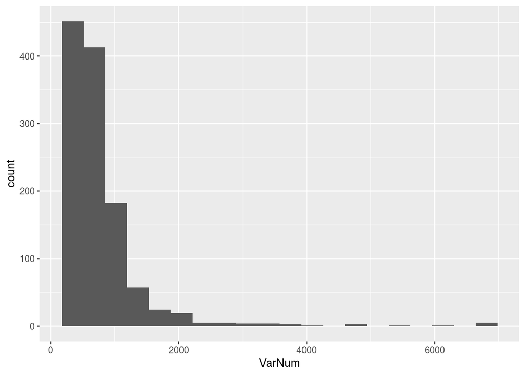

```r
library(ggplot2)
base1=ggplot(viaticos,aes(x=VarNum))
base1 + geom_histogram(bins = 20)
```

Veamos sus estadigrafos básicos:

```r
summary(VarNum)
```

```
##    Min. 1st Qu.  Median    Mean 3rd Qu.    Max.
##   320.0   320.0   640.0   738.8   960.0  6790.0
```

- ¿La variable se distribuye simetricamente?

```r
library(DescTools)
Skew(VarNum)
```

```
## [1] 4.937432
```

Se confirma que la asimetría es alta y positiva. Notese la distancia entre la mediana y la moda.

- ¿La variable tiene moda prominente?

```r
Kurt(VarNum)
```

```
## [1] 33.58728
```

Se confirma que la moda es prominente, la distribución es leptocurtica.

- ¿Habrá valores atípicos?

```r
sd(VarNum)
```

```
## [1] 689.6591
```

La desviación típica confirma una alta dispersion, considerando que es casi tan grande como la media:

```r
CoefVar(VarNum)
```

```
## [1] 0.9334578
```

Y dada la cola a la derecha, es lógico suponer que hay atípicos:

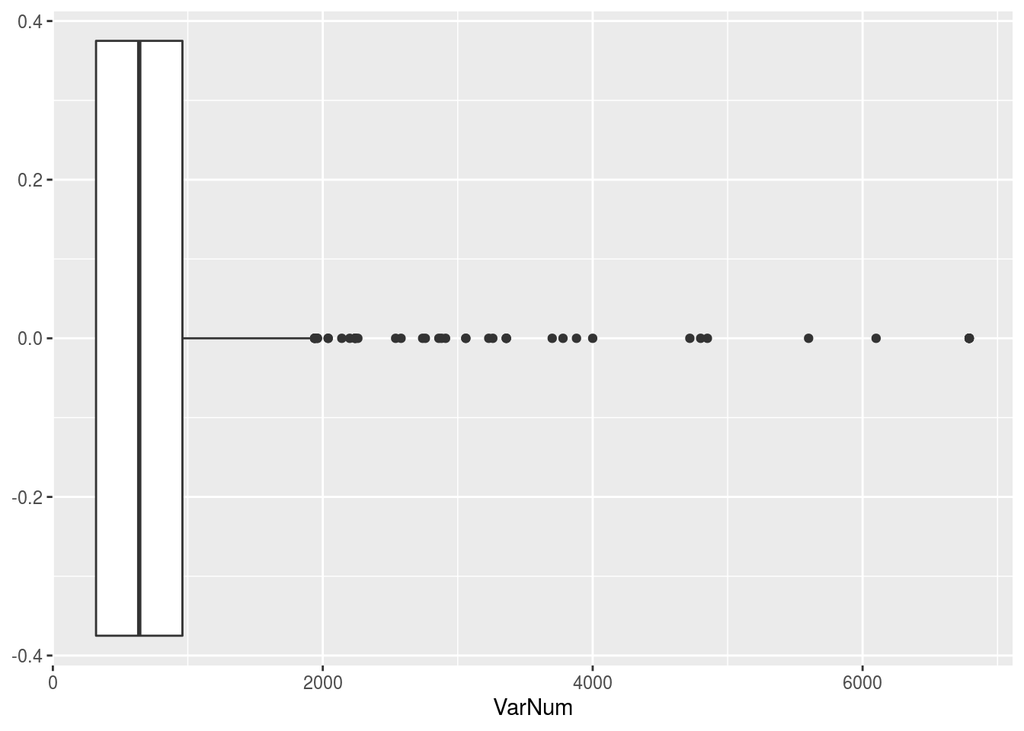

```r
base2=ggplot(viaticos,aes(y=VarNum))
base2 + geom_boxplot() + coord_flip()
```

Los atipicos comienzan a partir de:

```r
1.5*IQR(VarNum) + as.vector(summary(VarNum)[5])
```

```
## [1] 1920
```

Todo monto que supere ello se considera un valor atípico.

```r
length(VarNum[VarNum>1920])
```

```
## [1] 42
```

De los 1180, se tiene este porcentaje de montos considerados atípicos.

```r
length(VarNum[VarNum>1920])/1180
```

```
## [1] 0.03559322
```

Tenemos ademas el Indice de Gini para indicar si hay concentración (desigualdad). Mientras mas cercano a 1 hay desigualdad absoluta (una persona produce/recibe todos los valores); si está cerca a 0, todos producen/reciben lo mismo.

```r
Gini(VarNum)
```

```
## [1] 0.3537232
```

Podemos complementar con el gráfico de Lorenz:

```r
library(gglorenz) # instalar
```

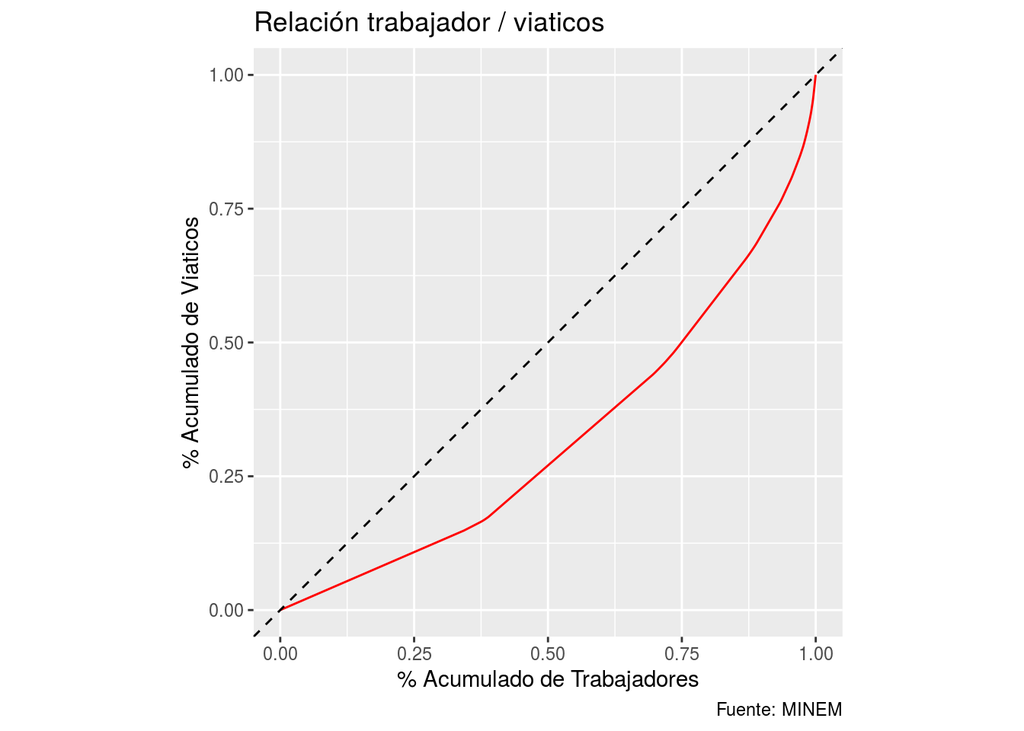

```r
base1 + stat_lorenz(color='red') +
    geom_abline(linetype = "dashed") + coord_fixed() +
    labs(x = "% Acumulado de Trabajadores",
         y = "% Acumulado de Viaticos",
         title = "Relación trabajador / viaticos",
         caption = "Fuente: MINEM")
```

Esta gráfica ayuda a su intepretación:

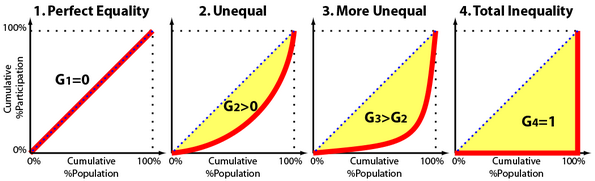

Tomado de: https://towardsdatascience.com/gini-coefficient-and-lorenz-curve-f19bb8f46d66

**Ejercicio:**

Utilice sus datos y calcule las medidas que correspondan.

[Volver al programa del curso](https://coursesandtutorials.github.io/Estadistica/)